# HW3

Use this R Notebook document to answer the questions and document your work. Enter the R code used to answer each question in the corresponding R code chunk. Write any textual explanations **outside** of the chunks. When we grade, we will *hide* the code and just look at the R output and your written answers. Attempt to clean up your code as much as possible so that only the necessary lines remain.

When you are done:

1. Select ‘Run All’ from the ‘Run’ dropdown menue.
2. Save (File -> Save)
3. Click ‘Preview’ to bring up the `HW1.nb.html` file. Check through this to make sure it rendered correctly.
4. Upload the `HW1.nb.html` to Canvas.

```r
# Necessary pacakges
library(ggplot2)
library(emmeans)
# the following 5 packages are new. You may have to install these using install.packages(c('car','lme4','lmerTest','pbkrtest','multcomp', 'multcompView'))
library(car)
library(lme4)
library(lmerTest)
# library(pbkrtest)
library(multcomp)
library(multcompView)
```

# 1 Question 1

In lab, we analyzed an experiment with subsamples. Multiple soil samples were taken per plot. It turns out that in a balanced experiment where every experimental unit has the same number of subsamples, you will get *exactly* the same answers if you first average the subsamples into a single mean response per plot, and then analyze the averaged data.

In this question, I want you to repeat the analyses presented in Lab3 after first averaging the subsamples per plot.

The following code loads the Sample-level data from lab and averages the Samples per Plot:

```r
clover <- read.csv('~/Desktop/R_Projects/PLS205_Winter2021/PLS205_Winter2021/data/Clover_data.csv')
summary(clover)
```

```
     Sample        Strain               Plot          NLevel
 Min.   :1.00   Length:120         Min.   : 1.0   Min.   : 7.30
 1st Qu.:1.75   Class :character   1st Qu.: 8.0   1st Qu.:15.68
 Median :2.50   Mode  :character   Median :15.5   Median :19.45
 Mean   :2.50                      Mean   :15.5   Mean   :19.98
 3rd Qu.:3.25                      3rd Qu.:23.0   3rd Qu.:24.45
 Max.   :4.00                      Max.   :30.0   Max.   :34.60
```

```r
clover_means <- aggregate(NLevel ~ Plot + Strain,clover,FUN = mean)
str(clover_means)
```

```
'data.frame':   30 obs. of  3 variables:
 $ Plot  : int  6 8 11 17 25 1 10 21 22 26 ...
 $ Strain: chr  "3DOk1" "3DOk1" "3DOk1" "3DOk1" ...
 $ NLevel: num  33 19.3 32.9 27 32.1 ...
```

## 1.1 Explain why the soil samples are subsamples, not experimental units

> Because the treatment is applied at the plot level, each plot is an experimental unit. The soil samples are not independent observations, and thus are subsamples of each plot.

## 1.2 Provide a new design table for the averaged data

**Design**: Completely randomized design

| Structure | Variable | Type | # levels | Experimental Unit |
| --- | --- | --- | --- | --- |
| Treatment | Strain | Categorical | 6 | Plot |
| Design | Plot | Categorical | 30 |  |
| Response | NLevel | Numeric | 30 |  |

## 1.3 Write the model for the averaged data and fit it with the appropriate model function

```r
clover_means_mod <- lm(NLevel ~ Strain, data = clover_means)
clover_means_mod
```

```
Call:
lm(formula = NLevel ~ Strain, data = clover_means)

Coefficients:
 (Intercept)  Strain3DOk13   Strain3DOk4   Strain3DOk5   Strain3DOk7
      28.865       -15.770       -14.335        -4.425        -8.600
  StrainComp
     -10.205
```

## 1.4 Show appropriate diagnostic plots and assess whether the data satisfy the model assumptions

Compare the plots to those generated in lab. Note: To replicate the `qqplot` and `Scale-Location` plot shown in Lab, you can use `plot(model,which=2:3)`

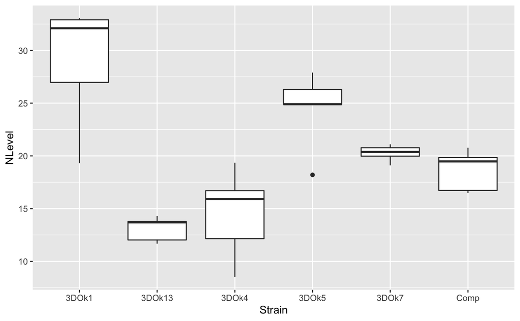

```r
#loading packages
library(ggplot2)

#inspecting the clover_means data
ggplot(clover_means,aes(x=Strain,y=NLevel)) + geom_boxplot()

#diagnostic plots for clover_means data
par(mfrow=c(1,2))
```

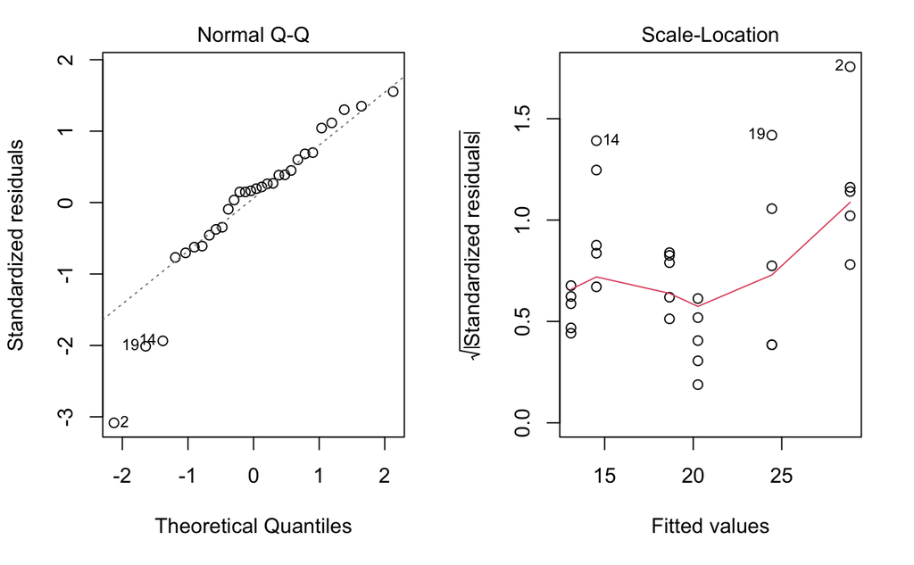

```r
plot(clover_means_mod,which = c(2,3))
```

> In the Normal Q-Q plot, the data fits reasonably well, although the data in the lower quantiles don’t fit as well as in the Lab 3 plots. This might mean that there is an issue with data in the lower quantiles, or (less likely) a transformation might be needed.

> In the Scale Location plot, the line is approximately horizontal, though there seems to be higher residual variances in the higher nitrogen levels. Again, this might warrant a transformation, but does not seem to be as severe as the plot generated in Lab 3.

## 1.5 Provide 95% confidence intervals for the effect of each of the 5 new strains relative to the control strain

Compare your results (means data) to the results from the full data (from lab) in R.

```r
summary(clover_means_vs_control,level = 0.95,infer = c(T,T))
```

```
 contrast      estimate   SE df lower.CL upper.CL t.ratio p.value
 3DOk1 - Comp     10.21 2.19 24     4.25   16.155  4.653  0.0005
 3DOk13 - Comp    -5.57 2.19 24   -11.52    0.385 -2.537  0.0726
 3DOk4 - Comp     -4.13 2.19 24   -10.08    1.820 -1.883  0.2488
 3DOk5 - Comp      5.78 2.19 24    -0.17   11.730  2.635  0.0591
 3DOk7 - Comp      1.60 2.19 24    -4.35    7.555  0.732  0.8740

Confidence level used: 0.95
Conf-level adjustment: dunnettx method for 5 estimates
P value adjustment: dunnettx method for 5 tests
```

> As expected, the confidence levels for both the “clover_means” data and the original “clover” data are exactly the same.

# 2 Question 2

| Drug |  |  |  |  |  |
| --- | --- | --- | --- | --- | --- |
| A_Steroid | 17.13 | 31.26 | 24.74 | 29.08 | 36.69 |
| B_Steroid | 20.82 | 45.82 | 29.52 | 27.35 | 24.08 |
| C_Dexamethasone | 29.08 | 53 | 48.69 | 42.13 | 36.63 |
| D_Dexamethasone | 31.26 | 30.17 | 41.04 | 17.13 | 11.69 |
| E_Old_standard | 55.17 | 49.74 | 48.62 | 37.78 | 35.61 |

```r
str(cough_data)
```

```
'data.frame':   25 obs. of  4 variables:
 $ Person: int  1 2 3 4 5 1 2 3 4 5 ...
 $ Drug  : chr  "A_Steroid" "A_Steroid" "A_Steroid" "A_Steroid" ...
 $ Type  : chr  "Steroid" "Steroid" "Steroid" "Steroid" ...
 $ Coughs: num  17.1 31.3 24.7 29.1 36.7 ...
```

## 2.1 Describe the design of this experiment in detail.

**Design**: Completely randomized design

| Structure | Variable | Type | # levels | Experimental Unit |
| --- | --- | --- | --- | --- |
| Treatment | Drug | Categorical | 5 | Person:Trial |
| Design | Person | Categorical | 5 |  |
| Design | Person:Drug | Categorical | 25 |  |
| Response | Cough | Numerical | 25 |  |

## 2.2 Visualize the data using a boxplot

Does it appear visually that there are differences among drugs? Do you see any data quality issues?

```r
ggplot(cough_data,aes(x=Drug,y=Coughs)) + geom_boxplot()
```

[output not shown]

## 2.3 Assess whether the assumptions of normality and equality of variances are satisfied by this data.

```r
# cough model
cough_model <- lm(Coughs ~ Drug + Person, data = cough_data)
cough_model
#diagnostic plots for cough_data
par(mfrow=c(1,2))
plot(cough_model,which = c(2,3))
```

[output not shown]

## 2.4 Estimate the effect of each of the drugs relative to the old standard

How strong is the evidence that any of the new drugs improve on the old standard? Provide appropriate 95% confidence intervals for each estimate Use `ref = X` in the call to emmeans to control which treatment level is treated as the control.

```r
# Comparing 4 new drugs to the old standard
cough_emmeans <- emmeans(cough_model, specs = 'Drug')
summary(cough_emmeans, level = 0.95, infer = c(T,F))

cough_vs_oldstd = contrast(cough_emmeans,
                                   method = 'trt.vs.ctrl',
                                   ref = "E_Old_Standard")
summary(cough_vs_oldstd,level = 0.95,infer = c(T,T))
```

[output not shown]

## 2.5 The company wants to move forward with a single drug - can you recommend one of the drugs over all the others?

This asks you to declare one drug to performs better than all others. - If you choose to recommend a drug, be very specific about what criteria you used, and declare your confidence in this conclusion. - If you choose not to recommend any specific drug, declare why you are not able to declare the best-performing drug the winner?

```r
# contrast table
cough_pairwise_diff = contrast(cough_emmeans,
                               method = 'pairwise')
summary(cough_pairwise_diff,level = 0.95,infer = c(T,F))

# SE pulled from contrast table generated above
SED <- 5.94

# finding t_c from the Tukey distribution
c_q = qtukey(p = 0.05,nmeans = 5,df = 20,lower.tail = F) / sqrt(2)
c_q

# minimum sig diff
MSD = c_q * SED
MSD

# grouping
cld(cough_emmeans,level = 0.95,Letters = letters)
```

[output not shown]

## 2.6 Now, the company decides they want to release a new Steroid drug, and a new Dexamethasone drug.

The following code splits the data into two separate datasets for each class of drug. Directly compare the two steroid drugs, and separately compare the two Dexamethasone drugs. **Can you recommend either steroid drug? Either Dexamethasone drug?** Use alpha = 0.05

```r
steroid_data <- subset(cough_data,Type == 'Steroid')
Dexamethasone_data <- subset(cough_data,Type == 'Dexamethasone')

# Steroid
steroid_model <- lm(Coughs ~ Drug + Person, data = steroid_data)

steroid_differences = emmeans(steroid_model, pairwise~Drug)

# Dexamethasone
dex_model <- lm(Coughs ~ Drug + Person, data = Dexamethasone_data)

dex_differences = emmeans(dex_model, pairwise~Drug)

# summaries
summary(steroid_differences,level = 0.95,infer = c(T,T))$contrast
summary(dex_differences,level = 0.95,infer = c(T,T))$contrast
```

[output not shown]

Your analysis should differ qualitatively from your analysis above (two drugs that were not distinguishable above are distinguishable here)

- Why would this analysis differ from the previous analysis? Differences may include: the set of questions, the calculation of SE, and the calculation of p-values / Confidence intervals
- Are the above p-values reasonable to report as evidence for a difference between either of the two pairs of drugs? This questions asks about the research question: “Are there differences between either of the steriod drugs OR either of the dexamethasone drugs?”